# Converting 10X sc-RNAseq to Tumor Deconvolution Benchmarking Data

Tom Snir

February 11, 2019

The following code will convert 10X sc-RNAseq data to files required to benchmark tumor deconvolution algorithms. To make things clearer, I go through several steps:

- Data cleaning and QC on the sc-RNAseq data
- Dimensionality reduction and clustering, finding differentially expressed genes.
- Extract from the clustering the type of data expected by Tumor Deconvolution algorithms
- Saving the files with the appropriate names and formats

The code below is used on a public 10X dataset, found at: https://s3-us-west-2.amazonaws.com/10x.files/samples/cell/pbmc3k/pbmc3k_filtered_gene_bc_matrices.tar.gz

# Part 1, loading and cleaning the sc-RNAseq data.

Public 10X data sets can be downloaded as a spare matrix (.mtx) with two additional files, barcodes.tsv and features.tsv (sometimes called genes), each a vector with the names of the cell barcodes and features/genes. The Seurat package which I’m using expects a folder with all 3 files present. Note that there is a raw version of the data and a filtered version, I am using the filtered version to avoid unnecessary complications.

```r
library(Seurat)
library(dplyr)
library(Matrix)
setwd("C:/Users/Tom Snir/Desktop/Dani/10X/3k_healthy/filtered_gene_bc_matrices/hg19")
```

Read the data and convert it to a Seurat Object, including only cells with at least 200 genes and genes expressed in at least 3 cells (~0.1% of the total number of cells)

```r
data.3k <- Read10X("C:/Users/Tom Snir/Desktop/Dani/10X/3k_healthy/filtered_gene_bc_matrices/hg19")

data.1 <- CreateSeuratObject(raw.data = data.3k,
                                          min.cells = 3,
                                          min.genes = 200,
                                          project = "healthy_10K")
```

Looking at the number of genes and UMIs, I decide to remove a few cells with unlikely values.

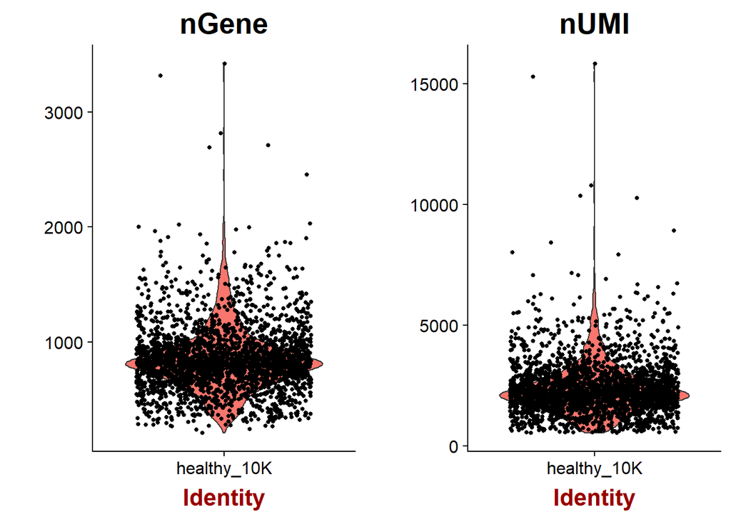

```r
#before QC

VlnPlot(object = data.1,
        features.plot = c("nGene", "nUMI"),
        nCol = 2)
```

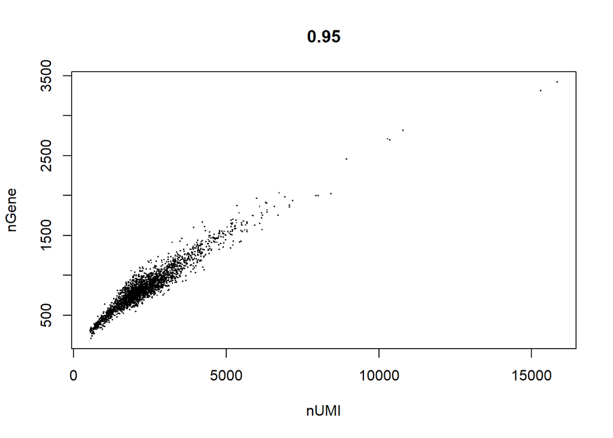

```r
GenePlot(object = data.1, gene1 = "nUMI", gene2 = "nGene", pch.use = '.')
```

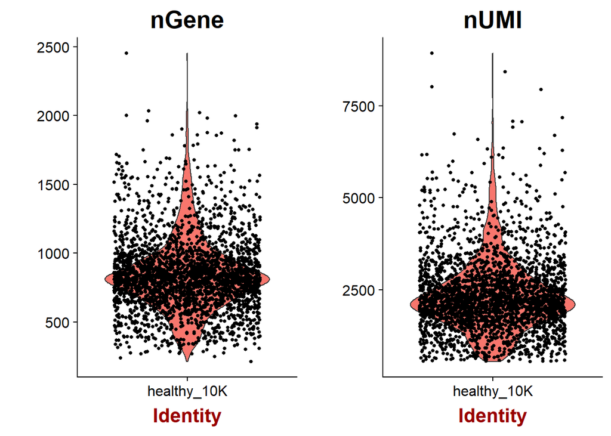

```r
#QC
data.2 <- FilterCells(object = data.1,
                         subset.names = c("nGene", "nUMI"),
                         high.thresholds = c(2500, 15000))



#after QC

VlnPlot(object = data.2,
        features.plot = c("nGene", "nUMI"),
        nCol = 2)
```

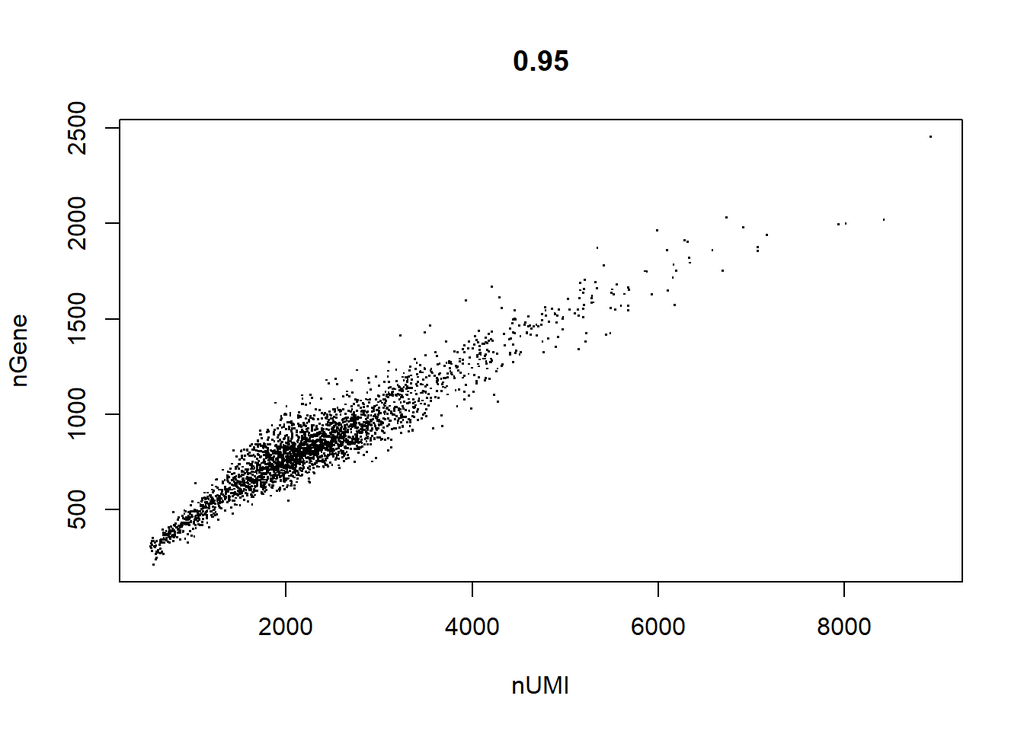

```r
GenePlot(object = data.2, gene1 = "nUMI", gene2 = "nGene", pch.use = '.')
```

Normalize the data:

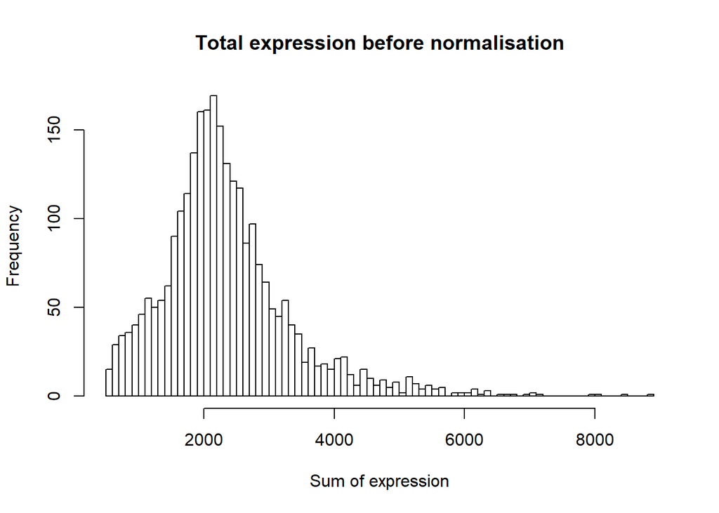

```r
#expression before normalization

hist(colSums(data.2@data),
     breaks = 100,
     main = "Total expression before normalisation",
     xlab = "Sum of expression")
```

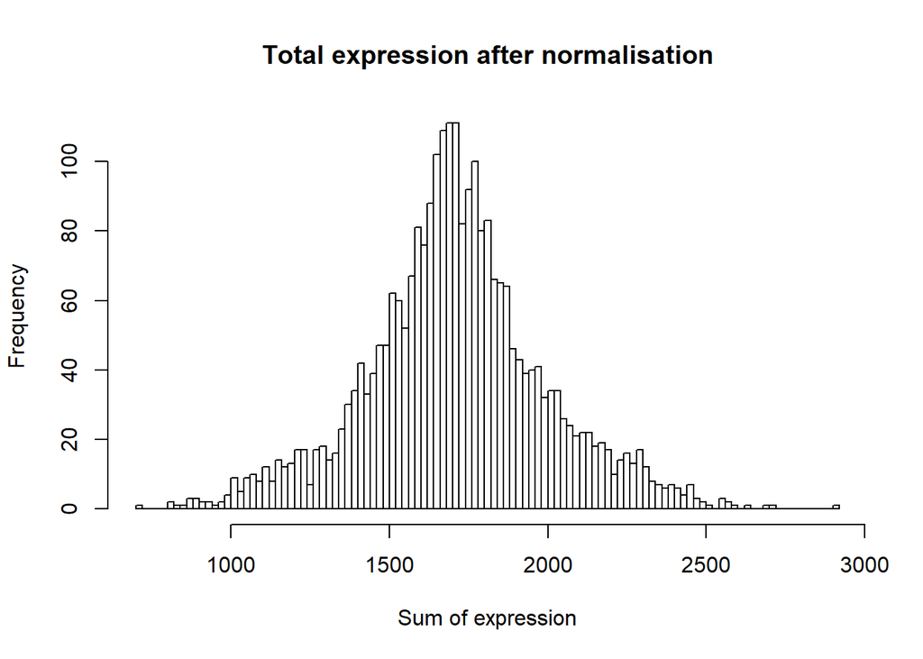

```r
#normalize
data.3 <- NormalizeData(object = data.2,
                           normalization.method = "LogNormalize",
                           scale.factor = 1e4)

#expression after normalization

hist(colSums(data.3@data),
     breaks = 100,
     main = "Total expression after normalisation",
     xlab = "Sum of expression")
```

Find variable genes and remove confounders

```r
data.3 <- FindVariableGenes(
  object = data.3,
  mean.function = ExpMean,
  dispersion.function = LogVMR,
  x.low.cutoff = 0.0125,
  x.high.cutoff = 3,
  y.cutoff = 0.5
)
```

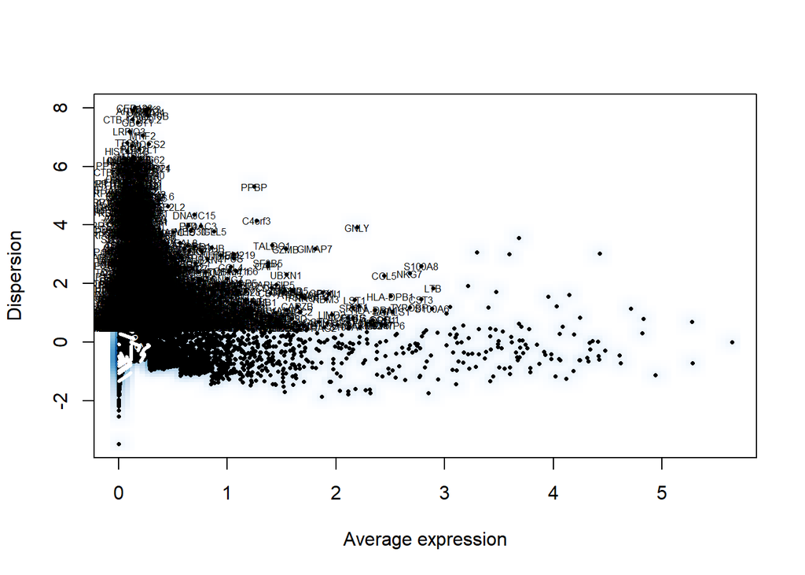

```r
length(data.3@var.genes)
```

```
## [1] 1864
```

```r
#remove confounders

data.3 <- ScaleData(
  object = data.3,
  vars.to.regress = c("nUMI")
)
```

```
##
## Time Elapsed:  9.7798638343811 secs
```

```
## Scaling data matrix
```

# Part 2, Dimensionality reduction and clustering, finding differentially expressed genes.

PCA

```r
data.3 <- RunPCA(
  object = data.3,
  pc.genes = data.3@var.genes,
  do.print = TRUE,
  pcs.print = 1:5,
  genes.print = 5
)
```

```
## [1] "PC1"
## [1] "CST3"   "FCN1"   "TYROBP" "LST1"   "AIF1"
## [1] ""
## [1] "IL32"  "LTB"   "CD2"   "CD247" "CTSW"
## [1] ""
## [1] ""
## [1] "PC2"
## [1] "NKG7" "GZMB" "CST7" "PRF1" "GZMA"
## [1] ""
## [1] "CD79A"    "MS4A1"    "HLA-DQA1" "TCL1A"    "HLA-DQB1"
## [1] ""
## [1] ""
## [1] "PC3"
## [1] "HLA-DPA1" "HLA-DPB1" "TYROBP"   "HLA-DRB1" "CD37"
## [1] ""
```

[output cut: 16 more lines]

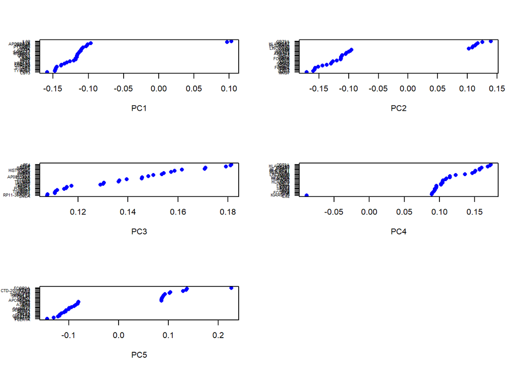

```r
VizPCA(object = data.3, pcs.use = 1:5)
```

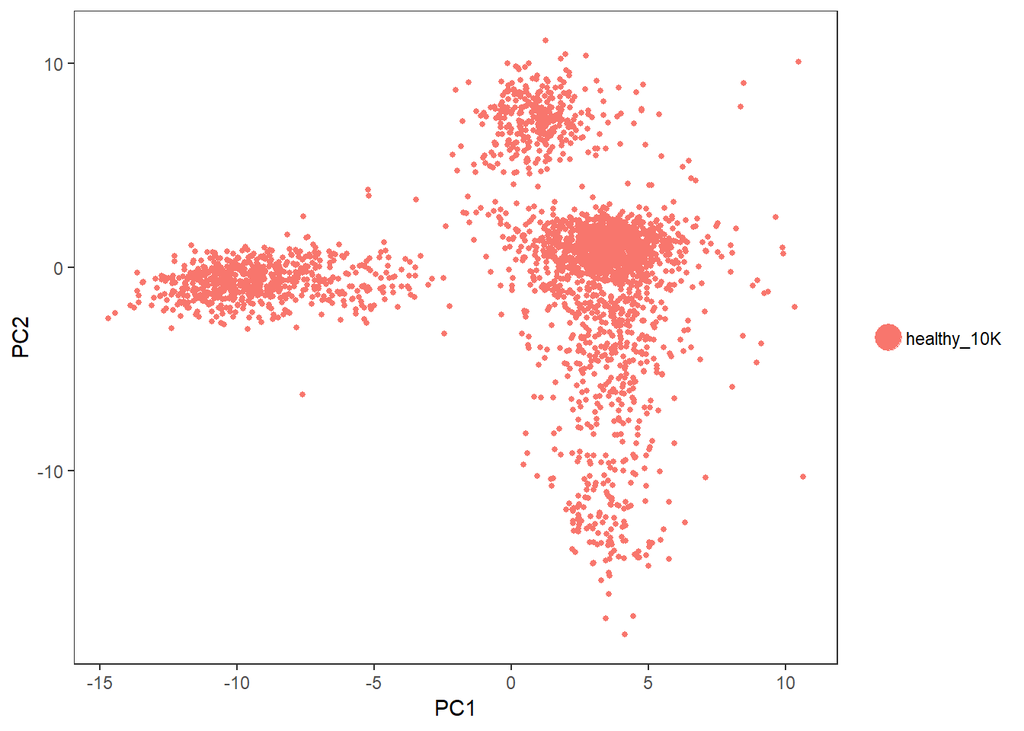

```r
PCAPlot(object = data.3, dim.1 = 1, dim.2 = 2)
```

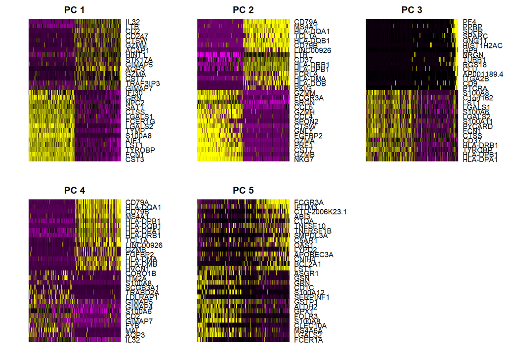

```r
PCHeatmap(
  object = data.3,
  pc.use = 1:5,
  cells.use = 500,
  do.balanced = TRUE,
  label.columns = FALSE,
  use.full = FALSE
)
```

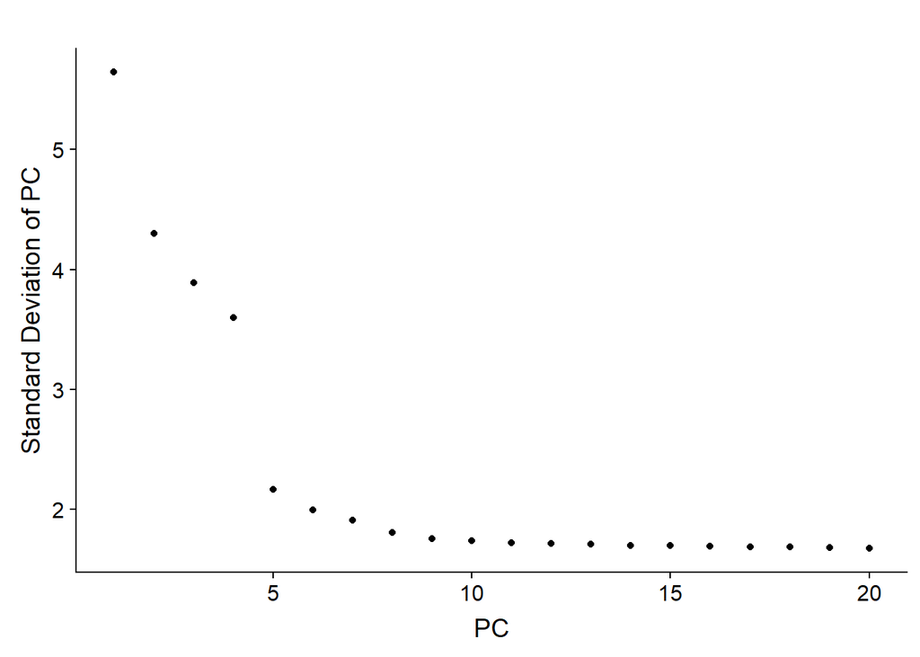

```r
PCElbowPlot(object = data.3)
```

Find clusters

```r
data.3 <- FindClusters(
  object = data.3,
  reduction.type = "pca",
  dims.use = 1:10,
  resolution = 0.6,
  print.output = 0,
  save.SNN = TRUE
)

PrintFindClustersParams(object = data.3)
```

```
## Parameters used in latest FindClusters calculation run on: 2019-02-11 11:40:12
## =============================================================================
## Resolution: 0.6
## -----------------------------------------------------------------------------
## Modularity Function    Algorithm         n.start         n.iter
##      1                   1                 100             10
## -----------------------------------------------------------------------------
## Reduction used          k.param          prune.SNN
##      pca                 30                0.0667
## -----------------------------------------------------------------------------
## Dims used in calculation
## =============================================================================
## 1 2 3 4 5 6 7 8 9 10
```

tSNE

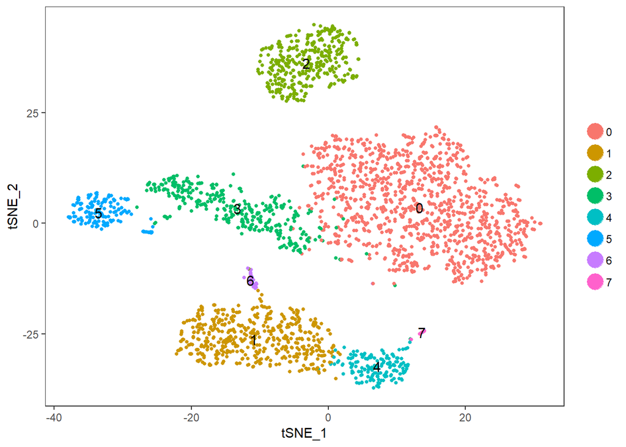

```r
data.3 <- RunTSNE(
  object = data.3,
  dims.use = 1:10,
  do.fast = TRUE
)

TSNEPlot(object = data.3, do.label = TRUE)
```